# A phylogenetic modelling tutorial using Phylogenetic Eigenvector Maps (PEM) as implemented in R package MPSEM (0.6-1)

Guillaume Guénard

2025-05-24

# Introduction

Phylogenetic Eigenvector Maps (**PEM**) is a method to perform phylogenetic modelling. Phylogenetic modelling consists in modelling trait evolution and predicting trait values using phylogeny as an explanatory factor (Guénard, Legendre, and Peres-Neto 2013). Phylogenetic modelling allows one to predict trait values when it is difficult or impractical to obtain them, for instance when species are rare, extinct, or when information is needed for several species and trait values are only available for a relatively small number of them (Guénard et al. 2011, 2014).

To apply phylogenetic modelling, one needs to have a set of species with known phylogeny and trait values (hereafter referred to as the *model species*) as well as to know the locations, with respect to the phylogeny of the models species, of the species for which trait values are being predicted (hereafter referred to as the *target species*). Phylogenetic modelling can be performed jointly with trait correlation modelling: it is possible to use other traits with known (or estimable) values for the target species to help predict a trait of interest. Phylogenetic trees being acyclic graphs, I will hereby prefer terms belonging to the graph theory over terms phylogeneticists may be more familiar with. Therefore I will use *edge* over *branches* and *vertex* over *root*, *node* or *tip*; safe in cases where I want to be specific about what a vertex represents.

### The Phylogenetic eigenvector maps (**PEM**) expression

> Statistical maps are a type of geographic map representing the values or states of a variable across space <https://encyclopedia2.thefreedictionary.com/statistical+map).

> In a paper entitled “The interpretation of statistical maps”, (Moran 1948) described tests of significance of the spatial relationships among values of qualitative variables on statistical maps.

> “Moran’s eigenvector maps” (**MEM**), an expression coined by Dray, Legendre, and Peres-Neto (2006), describes the variation of spatial eigenvectors whose eigenvalues are proportional to Moran’s I spatial autocorrelation statistics (Moran 1950) of the corresponding eigenvectors. Spatial eigenvectors are mathematical constructs that describe the variation of quantities across space (or time) at different spatial scales. They were originally called Principal Coordinates of Neighbour Matrices by Borcard and Legendre (2002).

> Phylogenetic eigenvector maps (**PEM**) (Diniz-Filho et al. 2012; Guénard, Legendre, and Peres-Neto 2013) are sets of eigenfunctions describing the structure of a phylogenetic graph, which represents either a Darwinian phylogenetic tree or a reticulated tree, i.e., a phylogenetic tree with reticulations. The various eigenvectors describe the variation across a phylogeny at different phylogenetic scales.

> Contrary to MEM, the eigenvalues in PEM are not proportional to Moran’s I autocorrelation coefficients of the corresponding eigenvectors.

The **PEM** work flow consists in

1. calculating the influence matrix of the graph,
2. specifying a model of trait evolution along the edges of the phylogenetic tree,
3. calculating the left eigenvectors of the weighted and centred influence matrix and
4. use these eigenvectors as descriptors (Guénard, Legendre, and Peres-Neto 2013).

An **R** language implementation of that approach is found in package **MPSEM**. **MPSEM** was developed to make the aforementioned process as seamless as possible. It is a work in progress; I welcome anyone to provide relevant suggestions and constructive remarks aimed at making **MPSEM** a better, more efficient and user-friendly, interface to phylogenetic modelling.

Assuming package **MPSEM** is installed, the first step to calculate a **PEM** is to load package MPSEM, which depends on packages **ape** and **MASS**:

```r
library(MPSEM)
```

# Preparing the data

For the present tutorial, we will use the data set **perissodactyla** from **R** package **caper**. These data from Purvis and Rambaut (1995) are loaded into your **R** workspace as follows:

```r
data(perissodactyla,package="caper")
```

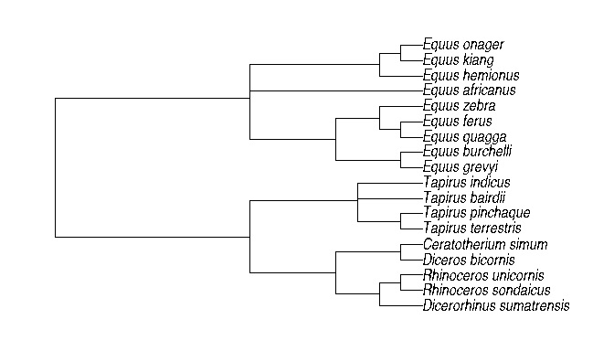

Fig. 1. The phylogenetic tree used for this example.

| Binomial | log.female.wt | log.neonatal.wt |
| --- | --- | --- |
| Ceratotherium simum | 6.262 | 4.903 |
| Dicerorhinus sumatrensis | 5.910 | 4.544 |
| Diceros bicornis | 6.183 | 4.699 |
| Equus africanus | 5.439 | 4.398 |
| Equus burchelli | 5.477 | 4.477 |
| Equus grevyi | 5.653 | 4.602 |
| Equus hemionus | 5.462 | 4.398 |
| Equus zebra | 5.462 | 4.398 |
| Rhinoceros sondaicus | 6.153 | 4.699 |
| Rhinoceros unicornis | 6.237 | 4.845 |
| Tapirus indicus | 5.455 | 3.919 |
| Tapirus pinchaque | 5.377 | 3.699 |
| Tapirus terrestris | 5.332 | 3.760 |

Before going any further, it is important to make sure that the species in the tree object are the same and presented in the same order as those in the data table. Glancing at the data table, species clearly cannot match since the latter feature information for only 13 of the 18 species in the tree. We will therefore match the tip labels of the original tree in the data table using the binary (Latin) species names in a character vector `spmatch`. When no matching element from the data table is found, the value `NA` appears at the corresponding position in `spmatch`. We can therefore use these missing values to reference the species that can be dropped from the tree using function `drop.tip()` from package **ape** as follows:

```r
match(
  perissodactyla.tree$tip.label,
  perissodactyla.data[,1L]
) -> spmatch

drop.tip(
  perissodactyla.tree,
  perissodactyla.tree$tip.label[is.na(spmatch)]
) -> perissodactyla.tree
```

Now that the data match the tree in terms of species content, we then need to make sure that species ordering also matches as follows:

```r
cbind(perissodactyla.tree$tip.label, perissodactyla.data[,1L])
```

```
##       [,1]                       [,2]
##  [1,] "Dicerorhinus sumatrensis" "Ceratotherium simum"
##  [2,] "Rhinoceros sondaicus"     "Dicerorhinus sumatrensis"
##  [3,] "Rhinoceros unicornis"     "Diceros bicornis"
##  [4,] "Diceros bicornis"         "Equus africanus"
##  [5,] "Ceratotherium simum"      "Equus burchelli"
##  [6,] "Tapirus terrestris"       "Equus grevyi"
##  [7,] "Tapirus pinchaque"        "Equus hemionus"
##  [8,] "Tapirus indicus"          "Equus zebra"
##  [9,] "Equus grevyi"             "Rhinoceros sondaicus"
## [10,] "Equus burchelli"          "Rhinoceros unicornis"
## [11,] "Equus zebra"              "Tapirus indicus"
## [12,] "Equus africanus"          "Tapirus pinchaque"
## [13,] "Equus hemionus"           "Tapirus terrestris"
```

Since they do not, we need to recalculate `spmatch` with the new, reduced, tree and re-order the data accordingly:

```r
match(
  perissodactyla.tree$tip.label,
  perissodactyla.data[,1L]
) -> spmatch

perissodactyla.data[spmatch,] -> perissodactyla.data

all(perissodactyla.tree$tip.label == perissodactyla.data[,1L])
```

```
## [1] TRUE
```

```r
perissodactyla.data[,1L] -> rownames(perissodactyla.data)
perissodactyla.data[,-1L] -> perissodactyla.data
```

Our data of interest now appear as follows:

|  | log.female.wt | log.neonatal.wt |
| --- | --- | --- |
| Dicerorhinus sumatrensis | 5.910 | 4.544 |
| Rhinoceros sondaicus | 6.153 | 4.699 |
| Rhinoceros unicornis | 6.237 | 4.845 |
| Diceros bicornis | 6.183 | 4.699 |
| Ceratotherium simum | 6.262 | 4.903 |
| Tapirus terrestris | 5.332 | 3.760 |
| Tapirus pinchaque | 5.377 | 3.699 |
| Tapirus indicus | 5.455 | 3.919 |
| Equus grevyi | 5.653 | 4.602 |
| Equus burchelli | 5.477 | 4.477 |
| Equus zebra | 5.462 | 4.398 |
| Equus africanus | 5.439 | 4.398 |
| Equus hemionus | 5.462 | 4.398 |

Finally, for the sake of demonstrating how to obtain predictions, we will remove the Sumatran rhinoceros (*Dicerorhinus sumatrensis*), the first species on top of the table) to obtain our training data set {`perissodactyla.train`}, keep the withdrawn data as {`perissodactyla.test`}, and calculate a tree without the target species:

```r
perissodactyla.data[-1L,,drop=FALSE] -> perissodactyla.train
perissodactyla.data[1L,,drop=FALSE] -> perissodactyla.test
drop.tip(
  perissodactyla.tree,
  tip = "Dicerorhinus sumatrensis"
) -> perissodactyla.tree.train
```

# Calculating **PEM**

## Edge weighting function

As previously announced, I use the vocabulary of the graph theory when describing **PEM**: a tree is a (directed) graph, a branch is an edge, and the root, nodes, and tips are vertices. **PEM** allows one to specify a model of trait evolution along the edges of the tree. The trait evolution model is a power function of the edge lengths, with parameters $a$ and $\psi$ describing the shape of the relationship between the edge lengths and trait evolution rate:

$$w_{a,\psi}(\phi_{j})=
\begin{cases}
\psi\phi^{\frac{1-a}{2}} & \phi_{j}>0\\
0 & \phi_{j}=0,
\end{cases}$$
where $a$ is the steepness parameter describing how abrupt the changes in trait values occur with time following branching, $\psi$ is the evolution rate of the trait, and $\phi_{j}$ is the length of edge $j$ (Guénard, Legendre, and Peres-Neto 2013).

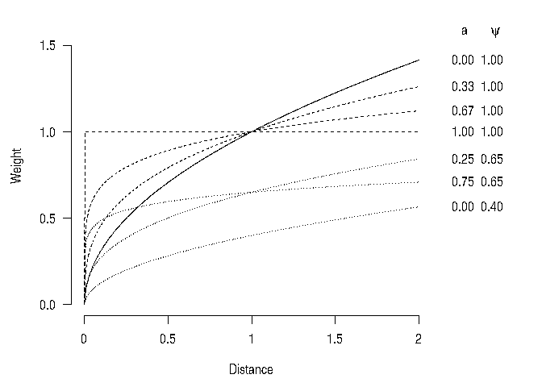

Fig. 2. Output of the edge weighting function for different sets of parameters $a$ and $\psi$.

As the steepness parameter increases, the weight assigned to a given edge increases more sharply with respect to the phylogenetic distance (or evolutionary time; Fig. 2). In the context of **PEM**, the edge weight represent the relative rate of evolution of the trait; the greater the edge weight, the greater the trait change along that edge. When $a=0$, trait evolution is neutral and therefore proceeds by random walk along edges. When $a=1$, edge weights no longer increase as a function of edge lengths. That situation corresponds to the scenario in which trait evolution is driven by the strongest possible natural selection: following a speciation event, trait either change abruptly (directional selection) at the vertex or do not change at all (stabilizing selection).

Also, the shape parameters may differ for different parts of the phylogenetic tree or network. For instance, the trait may have evolved neutrally at a steady rate from the base of a tree up to a certain node, and then, may have been subjected to different levels of selection pressure and various evolution rate from some of the nodes towards their descendent tips.

## Phylogenetic graph

The first step to build a **PEM** is to convert the phylogenetic tree. The is done by giving the tree to function `Phylo2DirectedGraph()` as follows:

```r
Phylo2DirectedGraph(
  perissodactyla.tree.train
) -> perissodactyla.pgraph
```

Here’s a snipet showing how the graph container used by **MPSEM** stores graph information:

```
## List of 2
##  $ edge  :List of 3
##   ..$         : num [1:21] 13 14 15 16 16 15 17 17 14 18 ...
##   ..$         : num [1:21] 14 15 16 1 2 17 3 4 18 19 ...
##   ..$ distance: int [1:21] 9 4 3 1 1 3 1 1 5 2 ...
##  $ vertex:List of 1
##   ..$ species: logi [1:22] TRUE TRUE TRUE TRUE TRUE TRUE ...
##  - attr(*, "ev")= int [1:2] 21 22
##  - attr(*, "class")= chr "graph"
##  - attr(*, "elabel")= chr [1:21] "E1" "E2" "E3" "E4" ...
##  - attr(*, "vlabel")= chr [1:22] "Rhinoceros sondaicus" "Rhinoceros unicornis" "Diceros bicornis" "Ceratotherium simum" ...
```

This list contains two main elements, `$edge` and `$vertex`, plus additional information. `$edge` and `$vertex` elements each contain a list of sub-elements:

- Element `$edge` is a list containing information about the edges of the graph, namely the indices of their origin and destination vertices (the two first unnamed elements) and an arbitrary number of supplementary elements storing other edge properties. In the present case, a numeric vector created by `Phylo2DirectedGraph()` and called `$distance` stores the phylogenetic distances ($\phi_{j}$), which, in this example, correspond to the branch lengths of `perissodactyla.tree`.
- The element `$vertex` is a list containing an arbitrary number of elements storing vertex properties. In the present case, a logical vector created by `Phylo2DirectedGraph()` and called `$species` stores whether a given vertex represents a species (*i.e.*, it is a tip) or not (*i.e.*, it is a node).
- In addition to edge and vertex information, the container stores other useful information in the form of attributes:
  - `ev` stores the number of edges and vertices.
  - `elabel` stores the edge labels.
  - `vlabel` stores the vertex labels.

## Building the eigenvector map

In **MPSEM**, **PEM** are build using function `PEM.build()`. As an example, let us assume that the steepness and evolution rate are $a=0.25$ and $\psi=2$ among genus *Equus*, $a=0.8$ and $\psi=0.5$ among genus *Tapirus*, and $a=0$ and $\psi=1$ from the root of the tree up to the vertex where the two latter genera begin as well as among the other genera. The following figure will help us figure out the indices of the edges involved:

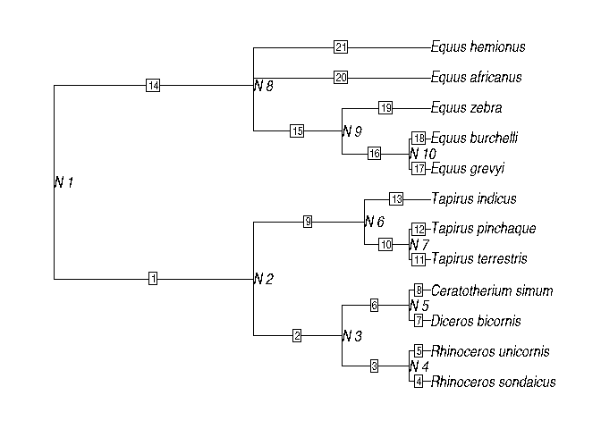

```r
perissodactyla.tree.train -> tree
paste("N",1L:tree$Nnode) -> tree$node.label

par(mar=c(2,2,2,2))
plot(tree,show.node.label=TRUE)

edgelabels(
  1L:nrow(tree$edge),
  edge=1L:nrow(tree$edge),
  bg="white",
  cex=0.75
)
```

Fig. 3. The labelled training species tree for this example.

```r
rep(0,attr(perissodactyla.pgraph,"ev")[1L]) -> steepness
rep(1,attr(perissodactyla.pgraph,"ev")[1L]) -> evol_rate

steepness[15L:21] <- 0.25
evol_rate[15L:21] <- 2
steepness[9L:13] <- 0.8
evol_rate[9L:13] <- 0.5
```

The **PEM** is obtained as follows:

```r
PEM.build(
  perissodactyla.pgraph,
  d="distance",
  sp="species",
  a=steepness,
  psi=evol_rate
) -> perissodactyla.PEM
```

In addition to the phylogenetic graph, function `PEM.build()` needs arguments `d`, the name of the edge property where the phylogenetic distances are stored, `sp`, the name of the vertex property specifying what vertex is a species, as well as the user-specified steepness and evolution rate. When the vectors given to arguments `a` or `psi`, have smaller sizes then the number of edges, the values are recycled. The default values for `d` and `sp` are those produced by `Phylo2DirectedGraph()`, and can therefore be omitted in most cases. The object that **MPSEM** uses to store **PEM** information is rather complex and we will hereby not browse through it. Method `as.data.frame` can be used to extract the eigenvector from the `PEM-class` object. For a set of $n$ species, that method returns a matrix encompassing at most $n-1$ column vectors that can be used in models to represent phylogenetic structure in traits. Here the phylogenetic patterns of variation described by two eigenvectors of the **PEM** we calculated above:

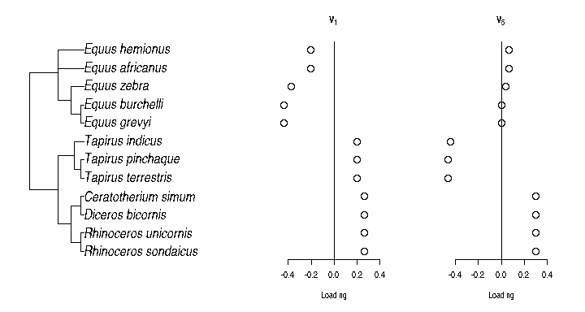

```r
layout(matrix(c(1,1,1,2,2,3,3),1L,7L))
par(mar=c(5.1,2.1,4.1,2.1))

## Singular vectors are extracted using the as.data.frame method:
as.data.frame(perissodactyla.PEM) -> perissodactyla.U

plot(perissodactyla.tree.train, x.lim=60, cex=1.5)
plot(y = 1L:nrow(perissodactyla.train), ylab="", xlab = "Loading",
     x = perissodactyla.U[,1L], xlim=0.5*c(-1,1),
     axes=FALSE, main = expression(bold(v)[1]), cex=1.5)
axis(1)
abline(v=0)

plot(y = 1L:nrow(perissodactyla.train), ylab="", xlab = "Loading",
     x = perissodactyla.U[,5L], xlim=0.5*c(-1,1),
     axes=FALSE, main = expression(bold(v)[5]), cex=1.5)
axis(1)
abline(v=0)
```

Fig. 4. Example of two eigenvectors obtained from the training species phylogeny.

## Estimate weighting parameters empirically

Because users do often not have information about the best set of weighting function parameters to use for modelling, **MPSEM** as has a function called `PEM.fitSimple()` that allows them to empirically estimate a single value of parameter $a$ for the whole phylogeny using restricted maximum likelihood. Function `PEM.fitSimple()` does not estimate parameter $\psi$ because the latter has no effect when its value is assumed to be constant throughout the phylogeny. A function to estimate different sets of weighting function parameters for different portions of the phylogeny has yet to be developed. That function requires a response variable that will be used to optimize the steepness parameter (here the $\log_{10}$ neonate weight) as well as lower and upper bounds for the admissible parameter values and is called as follows:

```r
PEM.fitSimple(
  y = perissodactyla.train[,"log.neonatal.wt"],
  x = NULL,
  w = perissodactyla.pgraph,
  d = "distance",
  sp="species",
  lower = 0,
  upper = 1
) -> perissodactyla.PEM_opt1
```

If other traits are to be used in the model (here the $\log_{10}$ female weight), they are passed to argument `x` as follows:

```r
PEM.fitSimple(
  y = perissodactyla.train[,"log.neonatal.wt"],
  x = perissodactyla.train[,"log.female.wt"],
  w = perissodactyla.pgraph,
  d = "distance",
  sp="species",
  lower = 0,
  upper = 1
) -> perissodactyla.PEM_opt2
```

The results of the latter calls are a **PEM** similar to that obtained using `PEM.build()`, with additional information resulting from the optimization process. It is noteworthy that estimates of the steepness parameter (stored as element `$optim\$par` of the **PEM** objects) and, consequently, the resulting phylogenetic eigenvectors, will be different depending on the use of auxiliary traits. In the example above, for instance, $a$ was estimated to 0 by `PEM.fitSimple()` when no auxiliary trait is involved (first call) and to 0.08 when the female weight is used as an auxiliary trait (second call).

## Phylogenetic modelling

To model trait values, **PEM** are used as descriptors in other modelling method. Any suitable method can be used. For instance, package **MPSEM** contains a utility function called `lmforwardsequentialAICc()` that does step-wise variable addition in multiple regression analysis on the basis of the corrected Akaike Information Criterion (AICc) (Hurvich and Tsai 1993):

```r
lmforwardsequentialAICc(
  y = perissodactyla.train[,"log.neonatal.wt"],
  object = perissodactyla.PEM_opt1
) -> lm1
summary(lm1)
```

```
##
## Call:
## lm(formula = as.formula(paste(p1, p2, sep = "")), data = df1)
##
## Residuals:
##       Min        1Q    Median        3Q       Max
## -0.122057 -0.053781 -0.004971  0.055333  0.186364
##
## Coefficients:
##             Estimate Std. Error t value Pr(>|t|)
## (Intercept)  4.39975    0.02740  160.58  < 2e-16 ***
## V_2          1.31105    0.09491   13.81  7.7e-08 ***
## ---
## Signif. codes:  0 '***' 0.001 '**' 0.01 '*' 0.05 '.' 0.1 ' ' 1
##
## Residual standard error: 0.09491 on 10 degrees of freedom
## Multiple R-squared:  0.9502, Adjusted R-squared:  0.9452
## F-statistic: 190.8 on 1 and 10 DF,  p-value: 7.699e-08
```

```r
lmforwardsequentialAICc(
  y = perissodactyla.train[,"log.neonatal.wt"],
  x = perissodactyla.train[,"log.female.wt",drop=FALSE],
  object = perissodactyla.PEM_opt2
) -> lm2
summary(lm2)
```

```
##
## Call:
## lm(formula = as.formula(paste(p1, p2, sep = "")), data = df1)
##
## Residuals:
##       Min        1Q    Median        3Q       Max
## -0.027763 -0.010050 -0.004766  0.013462  0.040954
##
## Coefficients:
##               Estimate Std. Error t value Pr(>|t|)
## (Intercept)   -2.67658    0.13764 -19.447 1.20e-06 ***
## log.female.wt  1.23979    0.02408  51.489 3.60e-09 ***
## V_1           -0.91755    0.02990 -30.687 7.95e-08 ***
## V_10          -0.09734    0.02590  -3.758  0.00942 **
## V_9           -0.08296    0.02577  -3.219  0.01816 *
## V_3            0.07184    0.02595   2.769  0.03248 *
## ---
## Signif. codes:  0 '***' 0.001 '**' 0.01 '*' 0.05 '.' 0.1 ' ' 1
##
## Residual standard error: 0.02575 on 6 degrees of freedom
## Multiple R-squared:  0.9978, Adjusted R-squared:  0.996
## F-statistic: 544.4 on 5 and 6 DF,  p-value: 6.963e-08
```

> It is noteworthy that in order to pass a single auxiliary trait to `lmforwardsequentialAICc()`, it is necessary, as exemplified above, to set `drop=FALSE` to the extraction operator (`[]`) to keep the `data.frame` property of the object. Hence, it is crucial that the auxiliary trait values be referenced with the same variable names in all `data.frame` objects involved in the analysis.

> Since, the extraction operator drops the `data.frame` property on its output object by default whenever a single column is selected, it is mandatory to set `drop=FALSE` when a single variable is (or could be) selected. A `data.frame` object is required for making predictions using the resulting linear model.

To obtain predictions, we need to calculate the locations of the target species with respect to the phylogeny of the model species. This is accomplished by `getGraphLocations()`, to which we give the tree for all species (model + targets) and the names (or indices) of the target species. Then, we use the `predict()` method for **PEM** objects. The latter takes, in addition to the **PEM** object, the locations of the target species as obtained by `getGraphLocations()`, an `lm` (or `glm`) object involving the eigenvectors of the **PEM**, and a table of auxiliary trait values for the target species, which can be omitted if no auxiliary trait is present in the linear model.

```r
getGraphLocations(
  perissodactyla.tree,
  targets = "Dicerorhinus sumatrensis"
) -> perissodactyla.loc

predict(
  object = perissodactyla.PEM_opt2,
  targets = perissodactyla.loc,
  lmobject = lm2,
  newdata = perissodactyla.test,
  interval = "prediction",
  level = 0.95) -> pred
```

Here, the predicted neonatal weight for the Sumatran rhinoceros is 26.7 $\,\mathrm{kg}$ and the bounds of the $95\%$ prediction interval are 17.5 and 40.6 $\,\mathrm{kg}$, while the observed value was actually 35 $\,\mathrm{kg}$.

# Cross-validating **PEM** predictions

Here is and example of how to perform a leave-one-out cross-validation of a data set using the **R** code from the previous two sections. Predictions will be added to table `perissodactyla.data`:

```r
data.frame(
  perissodactyla.data,
  predictions = NA,
  lower = NA,
  upper = NA
) -> perissodactyla.data

jackinfo <- list()
for(i in 1L:nrow(perissodactyla.data)) {
  jackinfo[[i]] <- list()
  getGraphLocations(
    perissodactyla.tree,
    targets = rownames(perissodactyla.data)[i]
  ) -> jackinfo[[i]][["loc"]]
  PEM.fitSimple(
    y = perissodactyla.data[-i,"log.neonatal.wt"],
    x = perissodactyla.data[-i,"log.female.wt"],
    w = jackinfo[[i]][["loc"]]$x
  ) -> jackinfo[[i]][["PEM"]]
  lmforwardsequentialAICc(
    y = perissodactyla.data[-i,"log.neonatal.wt"],
    x = perissodactyla.data[-i,"log.female.wt",drop=FALSE],
    object = jackinfo[[i]][["PEM"]]
  ) -> jackinfo[[i]][["lm"]]
  predict(
    object = jackinfo[[i]][["PEM"]],
    targets = jackinfo[[i]][["loc"]],
    lmobject = jackinfo[[i]][["lm"]],
    newdata = perissodactyla.data[i,"log.female.wt",drop=FALSE],
    interval = "prediction",
    level = 0.95
  ) -> predictions
  unlist(predictions) -> perissodactyla.data[i, c("predictions", "lower", "upper")]
}
rm(i, predictions)
```

Because the result of `getGraphLocations()` includes the phylogenetic graph without the target species *Dicerorhinus sumatrensis*, which was removed from the tree given as the argument `tpall` and can be found as its element `$x`, it is not necessary to re-calculate the tree with the target species dropped, as well as the phylogenetic graph, as we did previously for explanatory purposes. Also, the internal information about each cross-validation steps is stored into a list (hereby called `jackinfo`), in order for the details of the analyses to be accessible later on.

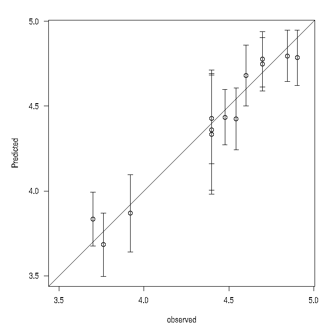

Fig. 5. Leave-one-out crossvalidated prediction of the neonatal weight for 13 odd-toed ungulate species.

From the present cross-validation, we found that the ($\log_{10}$) neonatal body mass can be predicted with a cross-validated $R^{2}$ of 0.96 (Fig. 5).

# Other utility functions

## Influence matrix

The influence matrix is used internally to calculate **PEM**. It is a matrix having as many rows as the number of vertices (species + nodes) and as many columns as the number of edges. Any given element of the influence matrix is coding whether a vertex, which is represented a row of the matrix is influenced an edge, which is represented by a column of the matrix. In the context of **PEM**, a vertex is influenced by an edge when the former has ancestors on the latter or, in other words, when an edge is on the path leading from a tip to the root of the tree. The influence matrix is obtained as follows:

```r
InflMat(perissodactyla.pgraph) -> res
res
```

```
##                      E1 E2 E3 E4 E5 E6 E7 E8 E9 E10 E11 E12 E13 E14 E15 E16 E17
## Rhinoceros sondaicus  1  1  1  1  0  0  0  0  0   0   0   0   0   0   0   0   0
## Rhinoceros unicornis  1  1  1  0  1  0  0  0  0   0   0   0   0   0   0   0   0
## Diceros bicornis      1  1  0  0  0  1  1  0  0   0   0   0   0   0   0   0   0
## Ceratotherium simum   1  1  0  0  0  1  0  1  0   0   0   0   0   0   0   0   0
## Tapirus terrestris    1  0  0  0  0  0  0  0  1   1   1   0   0   0   0   0   0
## Tapirus pinchaque     1  0  0  0  0  0  0  0  1   1   0   1   0   0   0   0   0
## Tapirus indicus       1  0  0  0  0  0  0  0  1   0   0   0   1   0   0   0   0
## Equus grevyi          0  0  0  0  0  0  0  0  0   0   0   0   0   1   1   1   1
## Equus burchelli       0  0  0  0  0  0  0  0  0   0   0   0   0   1   1   1   0
## Equus zebra           0  0  0  0  0  0  0  0  0   0   0   0   0   1   1   0   0
## Equus africanus       0  0  0  0  0  0  0  0  0   0   0   0   0   1   0   0   0
## Equus hemionus        0  0  0  0  0  0  0  0  0   0   0   0   0   1   0   0   0
## n1                    0  0  0  0  0  0  0  0  0   0   0   0   0   0   0   0   0
## n2                    1  0  0  0  0  0  0  0  0   0   0   0   0   0   0   0   0
## n3                    1  1  0  0  0  0  0  0  0   0   0   0   0   0   0   0   0
## n4                    1  1  1  0  0  0  0  0  0   0   0   0   0   0   0   0   0
## n5                    1  1  0  0  0  1  0  0  0   0   0   0   0   0   0   0   0
## n6                    1  0  0  0  0  0  0  0  1   0   0   0   0   0   0   0   0
## n7                    1  0  0  0  0  0  0  0  1   1   0   0   0   0   0   0   0
## n8                    0  0  0  0  0  0  0  0  0   0   0   0   0   1   0   0   0
## n9                    0  0  0  0  0  0  0  0  0   0   0   0   0   1   1   0   0
## n10                   0  0  0  0  0  0  0  0  0   0   0   0   0   1   1   1   0
##                      E18 E19 E20 E21
## Rhinoceros sondaicus   0   0   0   0
## Rhinoceros unicornis   0   0   0   0
## Diceros bicornis       0   0   0   0
## Ceratotherium simum    0   0   0   0
## Tapirus terrestris     0   0   0   0
## Tapirus pinchaque      0   0   0   0
## Tapirus indicus        0   0   0   0
## Equus grevyi           0   0   0   0
## Equus burchelli        1   0   0   0
## Equus zebra            0   1   0   0
## Equus africanus        0   0   1   0
## Equus hemionus         0   0   0   1
## n1                     0   0   0   0
## n2                     0   0   0   0
## n3                     0   0   0   0
## n4                     0   0   0   0
## n5                     0   0   0   0
## n6                     0   0   0   0
## n7                     0   0   0   0
## n8                     0   0   0   0
## n9                     0   0   0   0
## n10                    0   0   0   0
```

## Update and forced **PEM** parameters

The calculation of the influence matrix performed by `PEM.build()` for a given phylogenetic graph need not be done every time new weighting function parameters are to be tried. For that reason, **MPSEM** provides a function called `PEM.updater()` that takes a previously calculated **PEM** object, applies new edge weighting, and recalculates the phylogenetic eigenvectors:

```r
PEM.updater(object = perissodactyla.PEM, a = 0, psi = 1) -> res
res
```

```
## A phylogenetic eigenvector map (PEM) for  12  species:
## Rhinoceros sondaicus,Rhinoceros unicornis,Diceros bicornis,Ceratotherium simum,Tapirus terrestris,Tapirus pinchaque,Tapirus indicus,Equus grevyi ... Equus hemionus
## obtained from the following phylogenetic graph:
##
## A graph with 21 edges and 22 vertices.
## Edge labels: E1 E2 E3 E4 E5 E6 E7 E8 E9 E10 E11 E12 E13 E14 E15 E16 E17 E18 E19 E20 E21
## Vertex labels: Rhinoceros sondaicus Rhinoceros unicornis Diceros bicornis Ceratotherium simum Tapirus terrestris Tapirus pinchaque Tapirus indicus Equus grevyi Equus burchelli Equus zebra Equus africanus Equus hemionus n1 n2 n3 n4 n5 n6 n7 n8 n9 n10
## Available edge information:  distance
## Available vertex information:  species
```

The result of `PEM.build()` and `PEM.updater()` does not contain all the information necessary to predict trait values. Hence, neither of these functions is given information about the response variable and auxiliary traits. To perform these preliminary calculations, **MPSEM** provides the user with function `PEM.forcedSimple()` that produce the same output as `PEM.fitSimple()` with user-provided values of weighting parameters. It is called as follows:

```r
PEM.forcedSimple(
  y = perissodactyla.train[,"log.neonatal.wt"],
  x = perissodactyla.train[,"log.female.wt"],
  w = perissodactyla.pgraph,
  a = steepness,
  psi = evol_rate
) -> res
res
```

```
## A phylogenetic eigenvector map (PEM) for  12  species:
## Rhinoceros sondaicus,Rhinoceros unicornis,Diceros bicornis,Ceratotherium simum,Tapirus terrestris,Tapirus pinchaque,Tapirus indicus,Equus grevyi ... Equus hemionus
## obtained from the following phylogenetic graph:
##
## A graph with 21 edges and 22 vertices.
## Edge labels: E1 E2 E3 E4 E5 E6 E7 E8 E9 E10 E11 E12 E13 E14 E15 E16 E17 E18 E19 E20 E21
## Vertex labels: Rhinoceros sondaicus Rhinoceros unicornis Diceros bicornis Ceratotherium simum Tapirus terrestris Tapirus pinchaque Tapirus indicus Equus grevyi Equus burchelli Equus zebra Equus africanus Equus hemionus n1 n2 n3 n4 n5 n6 n7 n8 n9 n10
## Available edge information:  distance, a, psi
## Available vertex information:  species
```

It is noteworthy that contrary to function `PEM.fitSimple()`, function `PEM.forcedSimple()` can be used to apply different weighting parameters for different edges.

## **PEM** scores

**PEM** scores are the values of target species on the eigenfunctions underlying the **PEM**. These scores are calculated from the graph locations and a **PEM** object using function `Locations2PEMscores()` as follows:

```r
Locations2PEMscores(
  object = perissodactyla.PEM_opt2,
  gsc = perissodactyla.loc
) -> scores
scores
```

```
## $scores
##                                V_1      V_2         V_3          V_4       V_5
## Dicerorhinus sumatrensis 0.2439632 0.287517 -0.01215849 8.326673e-17 -0.351012
##                                    V_6         V_7          V_8           V_9
## Dicerorhinus sumatrensis -0.0007381739 0.005777055 6.101696e-16 -3.790663e-16
##                                   V_10          V_11
## Dicerorhinus sumatrensis -7.197828e-18 -1.160602e-16
##
## $VarianceFactor
##   Dicerorhinus sumatrensis
## y              0.004808351
```

The function is used internally by `PEM-class` `predict` method, and therefore need not be called when performing linear phylogenetic modelling as exemplified above. It comes in handy when the **PEM** is used together with other modelling approaches (e.g. multivariate regression trees, linear discriminant analysis, artificial neural networks) that have `predict` methods that are not specially adapted for phylogenetic modelling.

## Miscellaneous

Package **MPSEM** comes with functions, some implemented in the **C** language, to simulate quantitative traits evolution by Ornstein-Uhlenbeck process on potentially large phylogenies (Butler and King 2004). These functions are only useful to perform simulations, which is a rather advanced matter outside the scope of the present tutorial. I refer the user to **MPSEM** help files for further details.

In addition to function `Phylo2DirectedGraph()`, which we have seen previously **MPSEM** also has built-in graph manipulation functions to populate a graph with vertices, add and remove vertices and edges, etc. These functions were mainly intended to be called internally by **MPSEM** functions. They were made visible upon loading the package because of their potential usefulness to some advanced applications that are outside the scope of the present tutorial. Again, I refer the user to **MPSEM** help files for further details.

# References

Borcard, D., and P. Legendre. 2002. “All-Scale Spatial Analysis of Ecological Data by Means of Principal Coordinates of Neighbour Matrices.” *Ecological Modelling* 153: 51–68. https://doi.org/10.1016/S0304-3800(01)00501-4.

Butler, M. A., and A. A. King. 2004. “Phylogenetic Comparative Analysis: A Modeling Approach for Adaptive Evolution.” *American Naturalist* 164: 683–95. https://doi.org/10.1086/426002.

Diniz-Filho, J. A. F., L. M. Bini, T. F. Rangel, I. Morales-Castilla, M. A. Olalla-Tarraga, M. A. Rodrıguez, and B. A. Hawkins. 2012. “On the Selection of Phylogenetic Eigenvectors for Ecological Analyses.” *Ecography* 34: 239–49. https://doi.org/10.1111/j.1600-0587.2011.06949.x.

Dray, S., P. Legendre, and P. R. Peres-Neto. 2006. “Spatial Modelling: A Comprehensive Framework for Principal Coordinate Analysis of Neighbour Matrices (PCNM).” *Ecological Modelling*, 483–93. https://doi.org/10.1016/j.ecolmodel.2006.02.015.

Guénard, G., P. Legendre, and P. Peres-Neto. 2013. “Phylogenetic Eigenvector Maps: A Framework to Model and Predict Species Traits.” *Methods in Ecology and Evolution* 4: 1120–31. https://doi.org/10.1111/2041-210X.12111.

Guénard, G., P. C. von der Ohe, S. C. Walker, S. Lek, and P. Legendre. 2014. “Using Phylogenetic Information and Chemical Properties to Predict Species Tolerances to Pesticides.” *Proceedings of the Royal Society B: Biological Sciences* 281 (20133239): 20133239. https://doi.org/10.1098/rspb.2013.3239.

Guénard, G., P. C. von der Ohe, D. de Zwart, P. Legendre, and S. Lek. 2011. “Using Phylogenetic Information to Predict Species Tolerances to Toxic Chemicals.” *Ecological Applications* 21: 3178–90. https://doi.org/10.1890/10-2242.1.

Hurvich, C. M., and C.-L. Tsai. 1993. “A Corrected Akaike Information Criterion for Vector Autoregressive Model Selection.” *Journal of Time Series Analysis* 14: 271–79. https://doi.org/10.1111/j.1467-9892.1993.tb00144.x.

Moran, P. A. P. 1948. “The Interpretation of Statistical Maps.” *Journal of the Royal Statistical Society: Series B (Methodological)* 10: 243–51. https://doi.org/10.1111/j.2517-6161.1948.tb00012.x.

———. 1950. “Notes on Continuous Stochastic Phenomena.” *Biometrika* 37: 17–23. https://doi.org/10.1093/biomet/37.1-2.17.

Purvis, A., and A. Rambaut. 1995. “Comparative Analysis by Independent Contrasts (CAIC): An Apple Macintosh Application for Analysing Comparative Data.” *Computer Applications in the Biosciences* 11: 247–51. https://doi.org/10.1093/bioinformatics/11.3.247.